# Multiverse analysis study - Tutorial

## Introduction

Data analyses for any scientific research in an iterative, multi-stage process. The statistical results that are reported in a published paper are usually one of many reasonable analyses arising from the iterative process. A multiverse analysis aims to increase transparency by performing multiple analyses on a given dataset based on a set of defensible analysis procedures. In this tutorial, we will look at a simple example and you will complete extend the example in the following activity.

## Learning objectives

In this tutorial, you will practice defining and exploring a set of multiple analyses for a given dataset in R. You will:

- define multiple models using a inclusion-exclusion table and `apply()`,
- fit the models using `lapply()`,
- extract and save quantities of interest from the fitted models, and
- organize and visualize the extracted quantities to help answer a research question.

## Data

We are given a dataset that contains information on mortgage applications made in 1990 in Boston. We can read the dataset and store it in `hdma` as shown below. You can run the code below by clicking the green arrow button on the right of the code chunk or pressing ‘Ctrl + Shift + Enter’ with your cursor inside the code chunk to view the dataset.

```r
# the dataset is stored in the file named hdma.csv
hdma <- read.csv("hdma.csv")
hdma
```

| is_approved | is_female | is_black | is_married | is_housing_expense_ratio_high | is_self_employed | is_bad_credit | payment_income_ratio | loan_to_value_ratio |
| --- | --- | --- | --- | --- | --- | --- | --- | --- |
| 1 | 1 | 0 | 1 | 0 | 0 | 0 | 22.100 | 80.000000 |
| 1 | 0 | 0 | 0 | 0 | 0 | 0 | 26.500 | 92.187500 |
| 1 | 0 | 0 | 1 | 0 | 0 | 0 | 37.200 | 92.039801 |
| 1 | 0 | 0 | 1 | 0 | 0 | 0 | 32.000 | 86.046512 |
| 1 | 0 | 0 | 1 | 1 | 0 | 0 | 36.000 | 60.000000 |
| 1 | 0 | 0 | 1 | 0 | 0 | 0 | 24.000 | 51.052632 |
| 1 | 1 | 0 | 0 | 0 | 0 | 0 | 35.000 | 74.666667 |
| 1 | 0 | 0 | 1 | 0 | 0 | 0 | 28.000 | 85.000000 |
| 0 | 0 | 0 | 1 | 0 | 0 | 0 | 31.000 | 89.726027 |
| 1 | 0 | 1 | 1 | 0 | 0 | 0 | 24.000 | 94.814815 |

[output cut: 2499 more lines]

Each row of the dataset represents a mortgage application with the following information in the columns:

- `is_approved` is 1 if the application was approved and 0 otherwise.
- `is_female` is 1 if the applicant was a female and 0 otherwise.
- `is_black` is 1 if the applicant was a black or Hispanic and 0 if the applicant was non-Hispanic white. The dataset does not contain other races.
- `is_married` is 1 if the applicant was married and 0 otherwise.
- `is_housing_expense_ratio_high` is 1 if the bank’s calculation of housing expense over income exceeds 30% and 0 otherwise.
- `is_self_employed` is 1 if the applicant was self-employed and 0 otherwise.
- `is_bad_credit` is 1 if the applicant had one or more public records such as bankruptcy, charge offs, and collection actions and 0 otherwise.
- `payment_income_ratio` is the bank’s calculation of total debt payment over income in percentages.
- `loan_to_value_ratio` is the value of the loan amount over the appraisal value of the property in percentages.

## Research question

We are interested in answering the following research question.

> Did mortgage providers approve an application differently based on the applicant’s sex in Boston in 1990?

To answer the question, we can conduct a hypothesis test with the following set of hypotheses.

> - $H_0$: No, they were as likely to approve female applicants as male applicants.
> - $H_1$: Yes, they were either more likely or less likely to approve female applicants than male applicants.

We will conduct the test at 5% significance level, or 95% confidence level.

*Recall that a hypothesis test investigates whether a given data set provides evidence against the null hypothesis, $H_0$, which leads to the that the alternative hypothesis, $H_1$ is true.*

## A simple linear regression model

One way to conduct the hypothesis test for the given research question is the t-test for a single regression coefficient in a linear regression model. For example, we can fit the following simple linear regression model.

$$IsApproved_i = \beta_0 + \beta_1
IsFemale_i + \varepsilon_i$$

where $IsApproved_i$ is `is_approved` and $IsFemale_i$ is `is_female` for $i$th application in the dataset `hdma`.

In R, we can write the formula as `is_approved ~ is_female`. To fit the linear regression model, we can pass the formula and along with the dataset to the function `lm()` as below. Calling the `summary()` function on the fitted object provides a quick summary of the model.

**Run** the code below. This provides a summary of the fitted simple linear regression model.

```r
fit <- lm(formula = is_approved ~ is_female, data = hdma)
summary(fit)
```

```
##
## Call:
## lm(formula = is_approved ~ is_female, data = hdma)
##
## Residuals:
##     Min      1Q  Median      3Q     Max
## -0.8795  0.1205  0.1254  0.1254  0.1254
##
## Coefficients:
##             Estimate Std. Error t value Pr(>|t|)
## (Intercept) 0.874622   0.007407 118.074   <2e-16 ***
## is_female   0.004919   0.016224   0.303    0.762
## ---
## Signif. codes:  0 '***' 0.001 '**' 0.01 '*' 0.05 '.' 0.1 ' ' 1
##
## Residual standard error: 0.3301 on 2507 degrees of freedom
## Multiple R-squared:  3.666e-05,  Adjusted R-squared:  -0.0003622
## F-statistic: 0.09191 on 1 and 2507 DF,  p-value: 0.7618
```

The summary table provides the estimated coefficient of the term $IsFemale$, which is 0.004919. Recall that in the given dataset, a unit increase in $IsFemale$ indicates the applicant’s sex being female, 1, vs. male, 0. Thus, the coefficient is the mean gain in $IsApproved$ for female applicants vs. male applicants. $IsApproved$ was also encoded using 0 and 1 with 1 indicating an approved application. One way to interpret the result is that female applicants were approved for their mortgage applications with 0.4919% higher probability on average. However, this value does not indicate whether the difference is statistically significant.

The table provides the two-sided p-value for $IsFemale$, 0.762. When this value is smaller than the predefined significance level, we could conclude that the coefficient for $IsFemale$ does not equal to 0 at the significance level. In this case, since it is larger than our significance level, 0.05, we conclude that the result is not statistically significant and do not reject the null hypothesis.

> Using the the simple linear regression model, we do not find statistically significant evidence that an applicant’s sex was relevant in the probability of approval for their mortgage application. We fail to reject the null hypothesis that mortgage providers were as likely to approve female applicants as male applicants.

Alternatively, we can extract the 95% confidence interval for the coefficient estimate using `confint()`. The function by default outputs a table with 95% confidence intervals for all coefficients and the intercept. We can extract confidence interval for the $IsFemale$ term only by using the row name.

**Run** the code below. The code displays both the table of confidence intervals for all terms and the confidence interval extracted for the $IsFemale$ term.

```r
ci <- confint(fit)
ci # all confidence intervals
```

```
##                   2.5 %     97.5 %
## (Intercept)  0.86009706 0.88914765
## is_female   -0.02689571 0.03673321
```

```r
ci[row.names(ci) == "is_female", ] # extracting the is_female coefficient ci
```

```
##       2.5 %      97.5 %
## -0.02689571  0.03673321
```

*Recall that in R, you can select a subset of the rows in a table by passing the desired condition in the first index while leaving the second index empty, `<table>[<condition> , ]`.*

We can make the same conclusion that we can not reject the null hypothesis based on the fact that the confidence interval, (-0.027, 0.037), includes 0.

### *Practice*

Mortgage providers consider the applicant’s financial information when assessing an application. One may argue that the analysis above doesn’t consider this and that the following model is a better model to answer the research question.

$$IsApproved_i = \beta_0 + \beta_1
IsFemale_i + \beta_2 PaymentIncomeRatio_i + \varepsilon_i$$

where $IsApproved_i$ is `is_approved`, $IsFemale_i$ is `is_female`, and $PaymentIncomeRatio_i$ is `payment_income_ratio` for $i$th application in the dataset `hdma`.

In the code chunk provided below, fit the multiple linear regression defined above and extract the 95% confidence interval for the $IsFemale$ term.

```r
# write your code here
```

## Multiverse analysis

The dataset includes more than the payment to income ratio for each application. It includes other information about the applicant’s financial information as well as other demographic information. The mortgage providers also had access to them when making their decisions. However, it’s difficult to say that all of the information were relevant when making the decisions on the approvals.

Assume that any combination of the extra variables, or covariates, included in the dataset makes a defensible model for answering the research question. A multiverse analysis analyzes and reports results from all of the defensible models. For this tutorial, we will only consider `payment_income_ratio` and `is_married` as covariates.

### Defining the multiverse

With the 2 covariates, we can construct 4 defensible models in the following ways:

1. Do not include either `payment_income_ratio` or `is_married`
2. Include only `payment_income_ratio`
3. Include only `is_married`
4. Include both `payment_income_ratio` and `is_married`

In R, we can construct the formulae using all possible combinations of the two covariates programmatically.

**Run** each of the code chunks below to construct the formulae step by step.

1. Save the base formula `is_approved ~ is_female` to a variable.

```r
base_formula <- "is_approved ~ is_female"
```

2. Build a table that indicates the covariates to include in each model. `expand.grid()` creates a data frame that contains all possible combinations of the values in each input vector. In each column of `ie_table`, `TRUE` indicates that the covariate is included and `FALSE` indicates it is not. Each row represents a possible combination and you should see 4 rows.

```r
ie_table <- expand.grid(payment_income_ratio = c(TRUE, FALSE),
                        is_married = c(TRUE, FALSE))
ie_table
```

| payment_income_ratio | is_married |
| --- | --- |
| TRUE | TRUE |
| FALSE | TRUE |
| TRUE | FALSE |
| FALSE | FALSE |

3. Construct the formulae based on the table. We will make us of `apply()`. For each row, we will identify and add the covariate(s) indicated by the row to the base formula.

> `apply()` allows you to peform a task repeatedly using one row at a time from a table and save the results in a vector.

```r
covariates <- c("payment_income_ratio", "is_married")
# MARGIN = 1 indicates that we will apply the FUN along the rows
formulae <- apply(X = ie_table, MARGIN = 1, FUN = function(x) {
  # x is a row from ie_table evaluated one at a time
  # covariates[x] picks the covariate values where x is TRUE
  # paste(c(...), collapse = " + ") connects the elements in c(...) by " + "
  #   into a single string
  paste(c(base_formula, covariates[x]), collapse = " + ")
})
formulae
```

```
## [1] "is_approved ~ is_female + payment_income_ratio + is_married"
## [2] "is_approved ~ is_female + is_married"
## [3] "is_approved ~ is_female + payment_income_ratio"
## [4] "is_approved ~ is_female"
```

*Note that all 4 models include `is_approved` as the response variable and `is_female` as an explanatory variable since we are interested in the relationship between the two.*

You can check that `formualae` indeed stores 4 items using `length()`. Storing the value to a variable is also useful in the following steps.

```r
n_options <- length(formulae)
n_options
```

```
## [1] 4
```

### Fitting the multiverse

To fit the 4 models, we will use `lapply()`.

> Similar to `apply()`, `lapply()` allows you to perform a task repeatedly. The input can be a vector. The output will be a list.

For example, the following `lapply()` applied to the vector `formulae` calculates the number of characters for each item and saves them in a list. Note that you need double square brackets to access the individual items in a list.

```r
lapply(formulae, function(x) nchar(x))
```

```
## [[1]]
## [1] 59
##
## [[2]]
## [1] 36
##
## [[3]]
## [1] 46
##
## [[4]]
## [1] 23
```

For each of the model in the multiverse, we will

1. fit the linear regression model using the dataset `hdma`,
2. extract the coefficient estimate and 95% confidence interval for `is_female`, and
3. store the extracted estimate and confidence interval.

**Run** the code below. You should see a list of 4 vectors. Each vector consists of the coefficient estimates followed by the 95% confidence intervals for `is_female`.

```r
results_list <- lapply(formulae, function(x) {
  fit <- lm(x, data = hdma)
  # coefficients() extracts the coefficient estimates
  ests <- coefficients(fit)
  cis <- confint(fit)
  # extract the values for `is_female`
  est_is_female <- ests[names(ests) == "is_female"]     # ests is a vector
  ci_is_female <- cis[row.names(cis) == "is_female", ]  # cis is a table
  # return the coefficient estimate and the confidence interval in a vector
  return(c(est_is_female, ci_is_female))
})
results_list
```

```
## [[1]]
##   is_female       2.5 %      97.5 %
##  0.02684574 -0.00706864  0.06076012
##
## [[2]]
##    is_female        2.5 %       97.5 %
##  0.028984670 -0.005777891  0.063747230
##
## [[3]]
##    is_female        2.5 %       97.5 %
##  0.004978366 -0.026048895  0.036005627
##
## [[4]]
##    is_female        2.5 %       97.5 %
##  0.004918752 -0.026895707  0.036733212
```

*Note that because `ests` is a 1-dimensional vector, you need to filter using a 1-dimensional index, `[]`. Also, the vector only works with `names()` not `row.names()`.*

### Exploring the multiverse

In this tutorial example, we only considered decisions around inclusion and exclusion of 2 out of 7 covariates. As you will see in the following activity, a multiverse analysis can be complex and large. It is therefore important to organize and represent the results in a human-readable format to help answering the research question.

First, we will present the result in a table.

**Run** each of the code chunks below.

1. Combine the vectors in `results_list` into a single table.

```r
# do.call(ribnd, a_list) combines items in a_list row wise.
results <- do.call(rbind, results_list)
results
```

```
##        is_female        2.5 %     97.5 %
## [1,] 0.026845740 -0.007068640 0.06076012
## [2,] 0.028984670 -0.005777891 0.06374723
## [3,] 0.004978366 -0.026048895 0.03600563
## [4,] 0.004918752 -0.026895707 0.03673321
```

2. Create a data frame by putting the `results` table and `formulae` vector together with meaningful column names.

```r
# Define a data frame using the `results` table.
multiverse_table <- as.data.frame(results)
# Provide meaningful column names.
colnames(multiverse_table) <- c("Estimate", "LowerCI", "UpperCI")
# Add the vector `formulae` as the first column to the data frame.
multiverse_table <- cbind(Model = formulae, multiverse_table)
multiverse_table
```

| Model | Estimate | LowerCI | UpperCI |
| --- | --- | --- | --- |
| is_approved ~ is_female + payment_income_ratio + is_married | 0.026845740 | -0.007068640 | 0.06076012 |
| is_approved ~ is_female + is_married | 0.028984670 | -0.005777891 | 0.06374723 |
| is_approved ~ is_female + payment_income_ratio | 0.004978366 | -0.026048895 | 0.03600563 |
| is_approved ~ is_female | 0.004918752 | -0.026895707 | 0.03673321 |

We now have a table that presents the results from the multiverse analysis in a human-readable manner. From the table, we can see that all 4 analyses resulted in 95% confidence intervals that contain 0. We can also see from the table that including `is_married` as the covariate alone resulted in the largest coefficient estimate.

Visualizing the table can help explore and deduce conclusions from the multiverse analysis. We will use `ggplot2` library to visualize the results.

**Run** each of the code chunks below to construct a plot showing the estimates and the 95% confidence intervals from the 4 models. You can display the plot object in intermediate steps by calling `p`.

1. Load the library.

```r
library(ggplot2)
```

2. Define a canvas using the data. We will place `Model` along the y-axis. `aes()` allows mapping between the data frame’s columns and the plot’s axes and other aesthetic properties.

```r
p <- ggplot(multiverse_table, aes(y = Model))
```

3. Add points for `Estimate` values. `geom_point()` places points using values mapped to `x` and `y`.

```r
p <- p + geom_point(aes(x = Estimate))
```

4. Add lines representing the confidence intervals. `geom_linerange()` can place line segments using values mapped to `xmin`, `xmax`, and `y`.

```r
p <- p + geom_linerange(aes(xmin = LowerCI, xmax = UpperCI))
```

5. To highlight whether the confidence intervals cross 0, we can add a vertical line at 0. `geom_vline()` adds a vertical line at `xintercept`. We will also specify `linetype = "dotted"` to distinguish the vertical line from the confidence intervals.

```r
p <- p + geom_vline(xintercept = 0, linetype = "dotted")
```

6. Optionally, you can use a different theme such as `theme_minimal()`. It may help achieve a clean look that highlights plotted objects.

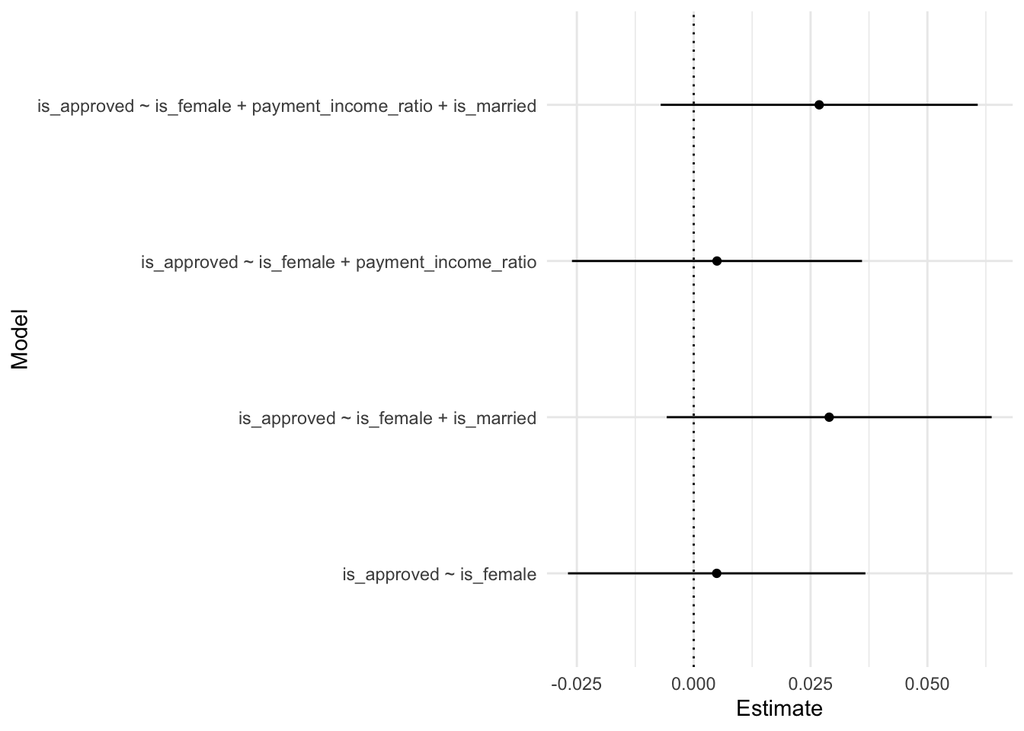

```r
p <- p + theme_minimal()
p
```

From the plot above, we can tell that while all 4 models resulted in positive coefficient estimates, the 95% confidence intervals all contain 0. To highlight which model resulted in the largest estimate of the `is_female` coefficient, we can sort the y-axis according to the value of `Estimate`.

**Run** the code below. To sort character values along an axis in `ggplot()`, we need to define it as a factor with the levels indicating the order.

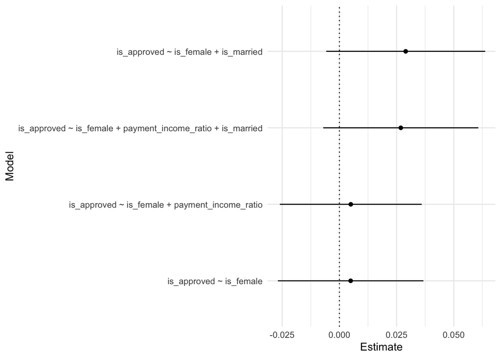

```r
multiverse_table$Model <- factor(
  multiverse_table$Model,
  # define levels according to the order of `Estimate`
  levels = multiverse_table$Model[order(multiverse_table$Estimate)]
)

ggplot(multiverse_table, aes(y = Model)) +
  geom_point(aes(x = Estimate)) +
  geom_linerange(aes(xmin = LowerCI, xmax = UpperCI)) +
  geom_vline(xintercept = 0, linetype = "dotted") +
  theme_minimal()
```

Looking at the plot, it’s clear that including `is_married` in the regression model resulted in higher coefficient estimates for `is_female`. To highlight the comparison between models with and without `is_married`, we can explicitly group the values by whether the model includes `is_married`.

**Run** the code below. Recall that `ie_table` specifies which covariates are included in each model. `facet_grid()` can create facets or subplots grouped by specified variable in rows (or columns). We set `scales = "free_y"` to remove unnecessary y axis labels.

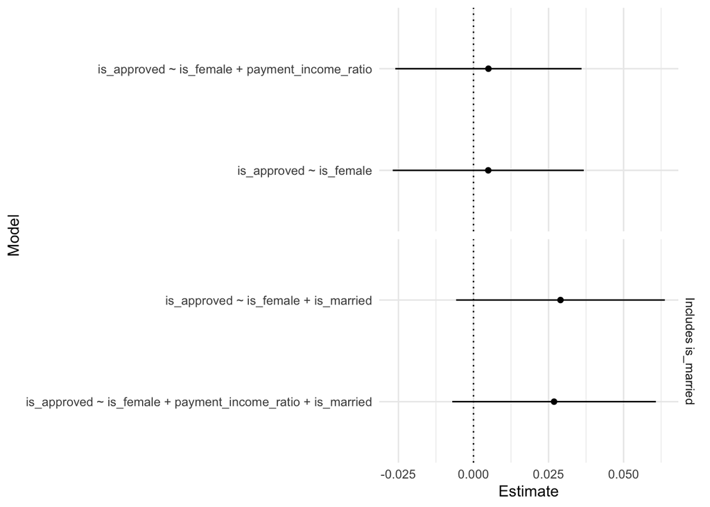

```r
multiverse_table['has_is_married'] <- ifelse(ie_table$is_married,
                                             "Includes is_married", "")

ggplot(multiverse_table, aes(y = Model)) +
  geom_point(aes(x = Estimate)) +
  geom_linerange(aes(xmin = LowerCI, xmax = UpperCI)) +
  geom_vline(xintercept = 0, linetype = "dotted") +
  theme_minimal() +
  # facet_grid() expects rows and cols wrapped in vars()
  facet_grid(rows = vars(has_is_married), scales = "free_y")
```

Suppose you want to highlight the model that includes both `is_married` and `payment_income_ratio`. You can use `&` to combine more than one logical checks to check that all of them are true.

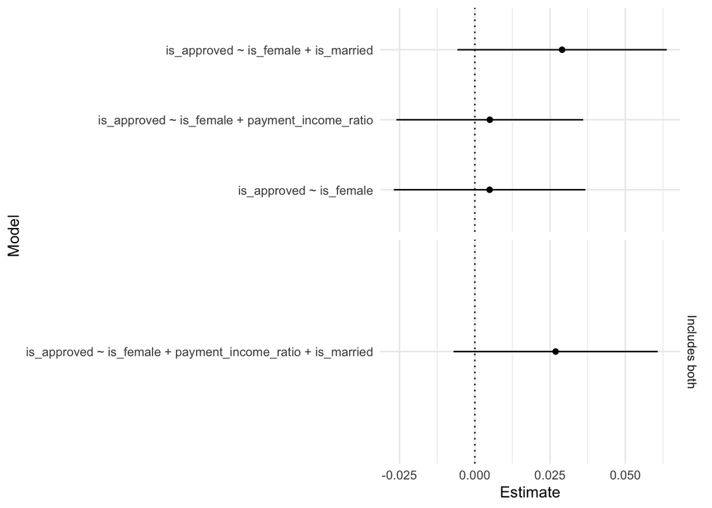

```r
multiverse_table['has_both'] <- ifelse(ie_table$is_married &
                                         ie_table$payment_income_ratio,
                                       "Includes both", "")

ggplot(multiverse_table, aes(y = Model)) +
  geom_point(aes(x = Estimate)) +
  geom_linerange(aes(xmin = LowerCI, xmax = UpperCI)) +
  geom_vline(xintercept = 0, linetype = "dotted") +
  theme_minimal() +
  # facet_grid() expects rows and cols wrapped in vars()
  facet_grid(rows = vars(has_both), scales = "free_y")
```

We may want to use short forms for the y-axis labels instead of including the full formulae. We can create a new column with `paste()` to create a numbered label for the models. You can use `factor()` to keep the ordering.

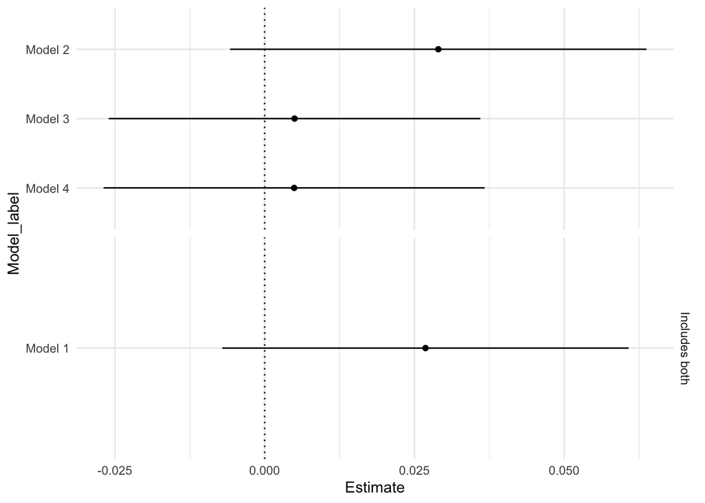

```r
multiverse_table["Model_label"] <- factor(
  paste("Model", 1:4),
  # define levels according to the order of `Estimate`
  levels = paste("Model", 1:4)[order(multiverse_table$Estimate)]
  )
ggplot(multiverse_table, aes(y = Model_label)) +
  geom_point(aes(x = Estimate)) +
  geom_linerange(aes(xmin = LowerCI, xmax = UpperCI)) +
  geom_vline(xintercept = 0, linetype = "dotted") +
  theme_minimal() +
  # facet_grid() expects rows and cols wrapped in vars()
  facet_grid(rows = vars(has_both), scales = "free_y")
```

> In all 4 models fitted in the multiverse analysis, we do not find statistically significant evidence that an applicant’s sex was relevant in the probability of approval for their mortgage application. The multiverse analysis further strengthened our conclusion from the simple linear regression analysis with no covariates. However, it’s worth noting that including the information about an applicant’s marital status visibly increased the estimated effect size.

Indeed, you will see that the larger multiverse analysis in the following activity consists of results that are both statistically significant and not.

> Knit the current document by clicking `knit` button at the top ro pressing `Shift + Ctrl + K`. Proceed back to the Quercus quiz. For the following activity, keep the rendered `tutorial.html` document open for reference.